# vignette for Package HW2

Jiayin(Joy) Li

2021-05-18

# HW2

The R Package *HW2* is a package contains three functions:solveols(), algoleverage(), elnetcoord(), from HW 1 for STSCI 6520: Computationally Intensive Statistical Methods.

To download and install the package, use `devtools`:

```r
library(devtools)
devtools::install_github("JiayinLi-3724/STSCI6520")
```

You can subsequently load the package with the usual R commands:

```r
library(HW2)
```

## A.Iterative Methods for Solving Linear System of Equations.

`solveols()`: solves a linear system using Gauss-Seidel or Jacobi method, allows user to specifyhow many cores to use for parallel implementation.

Apply Gauss-Seidel, Jacobi (sequential) and Jacobi (parallel), and plot the relative errors $\|x_k-v\|/\|v\|$ for first 1000 iterations against (a) number of iterations and (b) runtime.

```r
res.gs3=solveols("GaussSeidel",A=A3,v=v,iter=1000) #Gauss Seidel
res.js3=solveols("Jacobi",A=A3,v=v,iter=1000) #Jacobi(sequential)
res.jp3=solveols("Jacobi",cores=4,A=A3,v=v,iter=1000) #Jacobi(parallel)
```

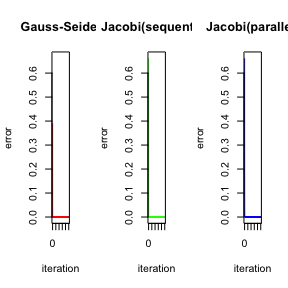

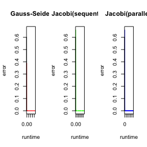

## B.Leveraging

`algoleverage()`: implements algorithmic leveraging for linear regression using uniform and leverage score based subsampling of rows.

Use the simulation setting for $r\in {10,50,100}$, and compare the performance of $\tilde{\beta}_{UNIF}$ and $\tilde{\beta}_{BLEV}$ , which use uniform and leverage score based sampling probabilities respectively. In particular, for every choice of $r$, report boxplots of $|\tilde{\beta}_{UNIF}-\hat{\beta}|$, and $|\tilde{\beta}_{BLEV}-\hat{\beta}|$ over 500 draws of subsample.

```r
#compare performance of estimated coefficients use uniform
d_unif10=algoleverage("unif",X,Y,n,r=10,replication=500,beta_ols=beta_ols)
d_unif50=algoleverage("unif",X,Y,n,r=50,replication=500,beta_ols=beta_ols)
d_unif100=algoleverage("unif",X,Y,n,r=100,replication=500,beta_ols=beta_ols)

#compare performance of estimated coefficients use leverage score based sampling probabilities
d_BLEV10=algoleverage("leverage",X,Y,n,r=10,Pi_2,replication=500,beta_ols=beta_ols)
d_BLEV50=algoleverage("leverage",X,Y,n,r=50,Pi_2,replication=500,beta_ols=beta_ols)
d_BLEV100=algoleverage("leverage",X,Y,n,r=100,Pi_2,replication=500,beta_ols=beta_ols)
```

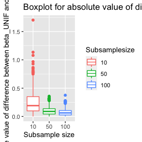

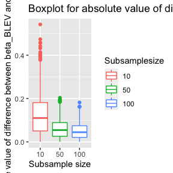

## C. Coordinate Descent for Elastic Net

`elnetcoord()`: fits elastic net to data using coordinate descent algorithm.

Plot the solution paths of `elnetcoord()` with $n=20$, $p=20$.

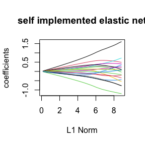

```r
p=20
n=20
mu <- rep(0,20)
Sigma <- diag(rep(1,20))
Sigma[1,2]=0.8
Sigma[2,1]=0.8
Sigma[5,6]=0.8
Sigma[6,5]=0.8
X=matrix(NA,n,p)
set.seed(65206520)
for (i in 1:n){X[i,]=MASS::mvrnorm(n=1, mu=mu, Sigma=Sigma)}
 beta=c(2,0,-2,0,1,0,-1,0,rep(0,12))
 set.seed(65206520)
 eps=rnorm(n,0,1)
 Y=X%*%beta+eps
M=elasticnet(X,Y,alpha=0,n,p,nlambda=100,tol=1e-5)
plot(colSums(abs(M[-1,])),M[2,],type="l", col="1",ylim=c(min(M[-1,]),max(M[-1,])),main="self implemented elastic net",xlab ="L1 Norm",ylab="coefficients")
for (i in 2:20){lines(colSums(abs(M[-1,])),M[i+1,],col=i)}
```